# Forêts aléatoires

Machine learning avance - Bertrand Roudier - ESIEE Paris

# 1. **Introduction**

## 1.1 Objectifs

- L’objectif de de TD est d’apprendre à réaliser une prédiction avec la méthode des forêts aléatoires en utilisant les packages (i) *randomForest* (forêts aléatoires) et (ii)  
  **randomForestExplainer** ( graphiques)
- Nous utiliserons le même jeux de données que celui utilisé avec la méthode CART. Ne pas oublier de transformer la variable à prédire en variable factorielle (puisqu’il s’agit d’une classification)
- Concernant la qualité de l’ajustement, nous utiliserons la fonction locale que nous avons décrite dans le TD sur la régression logistique multiple.

## 1.2 Rappels

Les méthodes classiques de classification et régression par arbre (CART, C4.5) présentent une grande facilité d’utilisation avec peu de travail préliminaire sur les jeux de données ( transformation des variables par exemple) car ils peuvent traiter à la fois des variables qualitatives et quantitatives (cf. cours arbres). En revencha, ils présentent une instabilité aux données de fait de leur structure hiérarchique : Un changement mineur dans les données peut induire une modification de la structure de l’arbre et par conséquence une modification de la prédiction surtout si cette modification affecte les premiers noeuds de l’arbre.

En agrégant des arbres de décisions, les forêts aléatoires permettent de remédier à ce problème. Ils augmentent en conséquence la robustesse en conservant tous les avantages des arbres. Le prix à payer est la lisibilité et l’interprétation des arbres.

Les forêts aléatoires permettent d’atteindre un pouvoir discriminant parmi les plus élevés de toutes les méthodes prédictives sans sur apprentissage qui se traduit par une meilleure généralisation tout en restant assez simple à paramètrer.

> sources: Tuffery Stéphane, (2015). *“Modélisation prédictive en apprentissage statistique avec R”*. Technip. 415p

# 2. **Environnement**

- Packages et jeux de données

```r
rm(list = ls())
LoadPack <- function(Packrequired)
{
  for(i in 1:length(Packrequired))
  {
    if(require(Packrequired[i], character.only = TRUE) == FALSE){install.packages(Packrequired[i])}
    library(Packrequired[i],character.only = TRUE)
  }
}
pack <- c('ggplot2','caret', 'pROC','reshape2', 'kableExtra','randomForest','randomForestExplainer', 'colorRamps' )
#-> chargement des packages
LoadPack(pack)
#-> Chargement des données
df1 <- read.table('heart.csv', header = T, sep = ',', dec = '.')

#-> Ne pas oublier de transformer la variable à prédire en variable factorielle
df1$HeartDisease = factor(df1$HeartDisease )

head(df1,10) %>% kbl() %>%  kable_styling( position = "center", full_width = FALSE)
```

| Age | Sex | ChestPainType | RestingBP | Cholesterol | FastingBS | RestingECG | MaxHR | ExerciseAngina | Oldpeak | ST_Slope | HeartDisease |
| --- | --- | --- | --- | --- | --- | --- | --- | --- | --- | --- | --- |
| 40 | M | ATA | 140 | 289 | 0 | Normal | 172 | N | 0.0 | Up | 0 |
| 49 | F | NAP | 160 | 180 | 0 | Normal | 156 | N | 1.0 | Flat | 1 |
| 37 | M | ATA | 130 | 283 | 0 | ST | 98 | N | 0.0 | Up | 0 |
| 48 | F | ASY | 138 | 214 | 0 | Normal | 108 | Y | 1.5 | Flat | 1 |
| 54 | M | NAP | 150 | 195 | 0 | Normal | 122 | N | 0.0 | Up | 0 |
| 39 | M | NAP | 120 | 339 | 0 | Normal | 170 | N | 0.0 | Up | 0 |
| 45 | F | ATA | 130 | 237 | 0 | Normal | 170 | N | 0.0 | Up | 0 |
| 54 | M | ATA | 110 | 208 | 0 | Normal | 142 | N | 0.0 | Up | 0 |
| 37 | M | ASY | 140 | 207 | 0 | Normal | 130 | Y | 1.5 | Flat | 1 |
| 48 | F | ATA | 120 | 284 | 0 | Normal | 120 | N | 0.0 | Up | 0 |

- Qualité de l’ajustement

```r
Valid_ROC <- function(obs, pred, direction = 0, threshold  = NULL, graph = T)
{
  require(pROC)
  require(caret)
  if(!is.factor(obs)){obs <- factor(obs)}
  lev        <- levels(obs)
  data_logit <- data.frame(obs = factor(obs), pred = pred)
  data_roc   <- roc(obs,pred)
  cir        <- ci(data_roc)
  data_spec  <- data.frame( sens    = data_roc$sensitivities ,
                            spec    = data_roc$specificities ,
                            thr     = data_roc$thresholds    ,
                            youden  = data_roc$sensitivities + data_roc$specificities - 1
                           )
  cir <- data.frame(roc = c(cir, youden = max(data_spec$youden) )) ; rownames(cir) <-c('AUC_lower','AUC','AUC_upper','youden')
  #-> si argument nulle alors calcul du seuil par la méthode de Youden
  if (is.null(threshold))
  {
    id       <- which.max(data_spec$youden) ; data_spec[id,] ;
    best_thr <- data_spec[id,3]
  }else{best_thr <- threshold}
  #-> binarisation
  if(direction == 0){dir_name <- lev[1] ; ndir_name <- lev[2] }else{dir_name = lev[2] ; ndir_name <- lev[1]}
  fac_roc    <- rep(dir_name,nrow(data_logit))
  id         <- which(pred >= best_thr) ; fac_roc[id] <- ndir_name ; fac_roc <- factor(fac_roc)
  conf_mat_1 <- confusionMatrix(fac_roc, obs)
  result     <- data.frame(Confusion = c(                 conf_mat_1$overall[1],
                                                          conf_mat_1$overall[3],
                                                          conf_mat_1$overall[4],
                                                          conf_mat_1$byClass[1],
                                                          conf_mat_1$byClass[2],
                                                          conf_mat_1$byClass[3],
                                                          conf_mat_1$byClass[4],
                                                          conf_mat_1$byClass[7],
                                                          Threshold  = best_thr
                                          )
                         )
  all_result <- list( result = result, Confusion = conf_mat_1$table, roc = cir)
  #--> graphique
  if(graph)
    {  data_gr    <- melt(data_spec, id.vars = 'thr')
       gr         <- ggplot(data = data_gr) + geom_line(aes(x = thr, y = value, color = variable )) +
       ylab('Probability') + xlab('threshold') + theme(legend.title = element_blank()) + geom_vline( xintercept = best_thr, color = '#0066CC')
      #--> courbe roc
      plot.roc(data_roc, print.auc=TRUE, print.thres=TRUE,col="#0066CC")
      all_result[['graph']] <- gr
  }
      return( all_result)
}
```

# 3. **Forêt Aléatoire avec *randomForest***

## 3.1 Arguments et appel

Les principaux arguments de la fonction (à connaitre) sont les suivants

- La fonction *randomForest* calcule des forêt aléatoire basées sur la méthode CART et effectue des mesure selon le principe *OOB* (cf.cours). Ce package est simple à utiliser. les principaux paramètres sont les suivants:
- **ntree** : Nombres d’arbres à agréger. par défaut, cette valeur est fixée à 500 qui correspond à un minimum (1000 est préférable)
- **mtry** : Nombre de variables à échantillonner parmi l’ensemble des variables prédictives - $\sqrt p$ en classement et $p/3$ en régression
- **nodesize** : Nombre d’éléments minimal dans les feuilles terminales. Par défaut, on utilise 1 en classement et 5 en régression
- **replace** : Par défaut = True: permet de réaliser le Boostrap sur les individus. il est donc impératif de ne pas modifier cet argument.
- **importance** : Par défaut = True: permet de calculer ultérieurement l’importance des variables
- **keepforest** : Par defaut = True: permet de conserver en mémoire la forêt en sortie afin de pouvoir l’utiliser sur un autre échantillon (en phase de validation)
- **xtest, ytest** : La fonction réalise une prédiction sur des valeurs tests sur lesquelles pourront être calculés la matrice des confusion et la ROC. On peut donc se demander pourquoi garder 15% du jeux de données en déploiement puisque la fonction réalise déjà une prédiction. En fait, même si cela parait en théorie inutile, il est toujours important de s’assure de la reproductibilité des résultats.

Partitionnement du jeux de données

- On utilise 85 % du jeux de données initial (partition 1) pour le paramétrage et la réalisation du modèle pour la phase d’entraînement et prédiction. Les 15% restant -(partition 2) nous permettra de réaliser une autre prédiction pour la phase de déploiement.
- Parmi les 85% de la partition 1, on sélectionne 70% des données en entrainement et 30% en prédiction

```r
set.seed(457867)
#--> Données de déploiement
id_dep   <- createDataPartition(1:nrow(df1), p = 0.15, list = F)
XY_dep   <- df1[id_dep, ]   ; X_dep <- df1[  id_dep, 1:11] ; Y_dep <- df1[  id_dep,12]
#--> Données en entrainement et en test
XY        <- df1[- id_dep, ] ; X     <- df1[- id_dep, 1:11] ; Y    <- df1[- id_dep,12]
id_test   <- createDataPartition(1:nrow(XY), p = 0.3, list = F)
XY_test   <- XY[  id_test, ] ; X_test  <- XY[  id_test, 1:11] ; Y_test  <- XY[  id_test,12]
XY_train  <- XY[- id_test, ] ; X_train <- XY[- id_test, 1:11] ; Y_train <- XY[- id_test,12]
```

Appel la fonction du package avec les arguments suivants :

```r
set.seed(547213)
n_tree = 1000

rf1 <- randomForest(HeartDisease~., data = XY_train           ,
                    ntree       = n_tree                      ,
                    mtry        = floor(sqrt(ncol(X_train)))  ,
                    nodesize    = 1                           ,
                    replace     = T                           ,
                    importance  = T                           ,
                    keep.forest = T                           ,
                    proximity   = T                           ,
                    na.action   = na.omit                     ,
                    xtest       = X_test                      ,
                    ytest       = Y_test                      ,
                   )
```

## 3.2 Résultats

La fonction retourne une liste contenant différents résultats. Ils concernent d’une part, ceux obtenus sur les données d’entraînement (XY_train) et d’autre part, ceux obtenus sur le jeu de données test (X_test, Y_test). Les résultats importants à analyser :

- Identification des OOB : Il es possible de savoir, pour chaque individu, le nombre d’arbre pour lequel il est OOB. les valeurs sont stockées dans la variable *oob.time*. Les 10 premières valeurs sont les suivantes:

| Ind | OOB |
| --- | --- |
| ind_1 | 358 |
| ind_2 | 345 |
| ind_3 | 358 |
| ind_4 | 370 |
| ind_5 | 351 |
| ind_6 | 348 |
| ind_7 | 374 |
| ind_8 | 370 |
| ind_9 | 358 |
| ind_10 | 389 |

- Taux d’erreur en entrainement et en validation. Les matrices *err.rate* et *test$err.rate* contiennent :
  - 1000 lignes, c.a.d le nombre d’arbres à agréger (défini par *ntrees*). Chaque ligne correspond donc au taux d’erreur de classement des individus par agrégation successive des arbres
  - La première colonne contient le taux d’erreur OOB Total, la deuxième colonne contient le taux d’erreur sur la première classe de Y (= 0) et la troisième colonne, le taux d’erreur sur la seconde classe de Y (= 1). Le tableau suivant fournit les résultats (10 premiers arbres) des erreurs en entrainement

| OOB | 0 | 1 |
| --- | --- | --- |
| 0.2051282 | 0.2307692 | 0.1880342 |
| 0.2215190 | 0.2000000 | 0.2365591 |
| 0.2098446 | 0.2024540 | 0.2152466 |
| 0.2022472 | 0.1736842 | 0.2235294 |
| 0.2105263 | 0.2028986 | 0.2164179 |
| 0.1876248 | 0.1954545 | 0.1814947 |
| 0.2042389 | 0.1929825 | 0.2130584 |
| 0.1947070 | 0.1802575 | 0.2060811 |
| 0.1826742 | 0.1794872 | 0.1851852 |
| 0.1700935 | 0.1822034 | 0.1605351 |

- On peut donc suivre à l’aide d’un graphique l’évolution des taux d’erreurs totaux en OOB sur le jeux d’entrainement (XY_train) mais aussi et surtout sur le jeux de données de test (X_test,Y_test). la comparaison des taux (entrainement et test) permettent de voir la qualité de l’ajustement et éventuellement modifier la paramétrage si besoin.

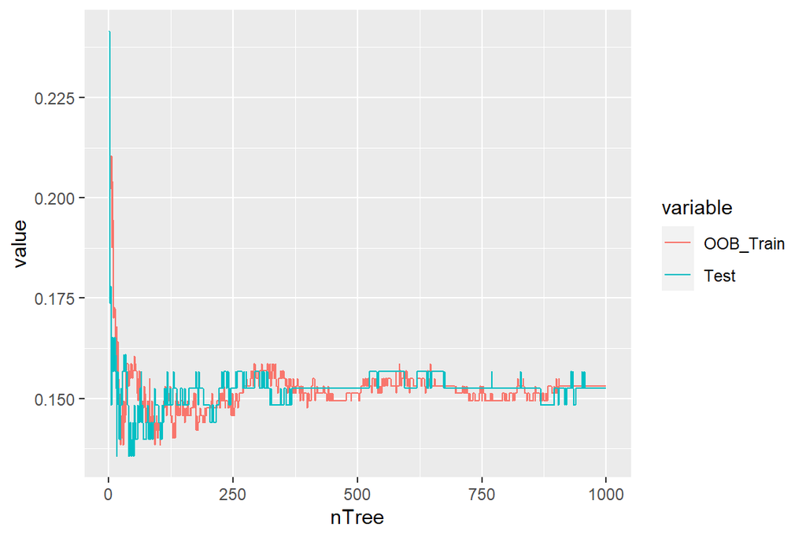

## 3.3 Qualité des résultats

On peut calculer les courbes ROC en test à laide de la fonction *Valid_Roc*. Les résultats sont les suivants :

**rmq** : On utilise la fonction *predict* pour estimer les prédictions en probabilité (*type = ‘prob’*)

|  | 0 | 1 |
| --- | --- | --- |
| 3 | 0.932 | 0.068 |
| 9 | 0.245 | 0.755 |
| 11 | 0.998 | 0.002 |
| 13 | 0.999 | 0.001 |
| 15 | 0.989 | 0.011 |
| 20 | 0.661 | 0.339 |
| 26 | 0.999 | 0.001 |
| 31 | 0.441 | 0.559 |
| 32 | 0.944 | 0.056 |
| 34 | 0.350 | 0.650 |

- Courbe ROC

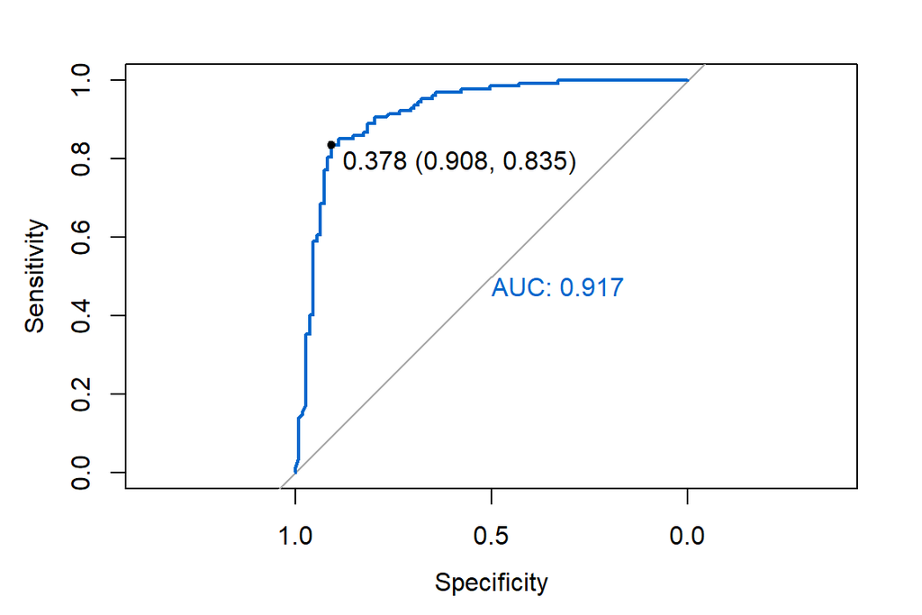

|  | roc |
| --- | --- |
| AUC_lower | 0.8792034 |
| AUC | 0.9172506 |
| AUC_upper | 0.9552978 |
| youden | 0.7429026 |

- Evolution des spécificités, sensibilités et seuillage

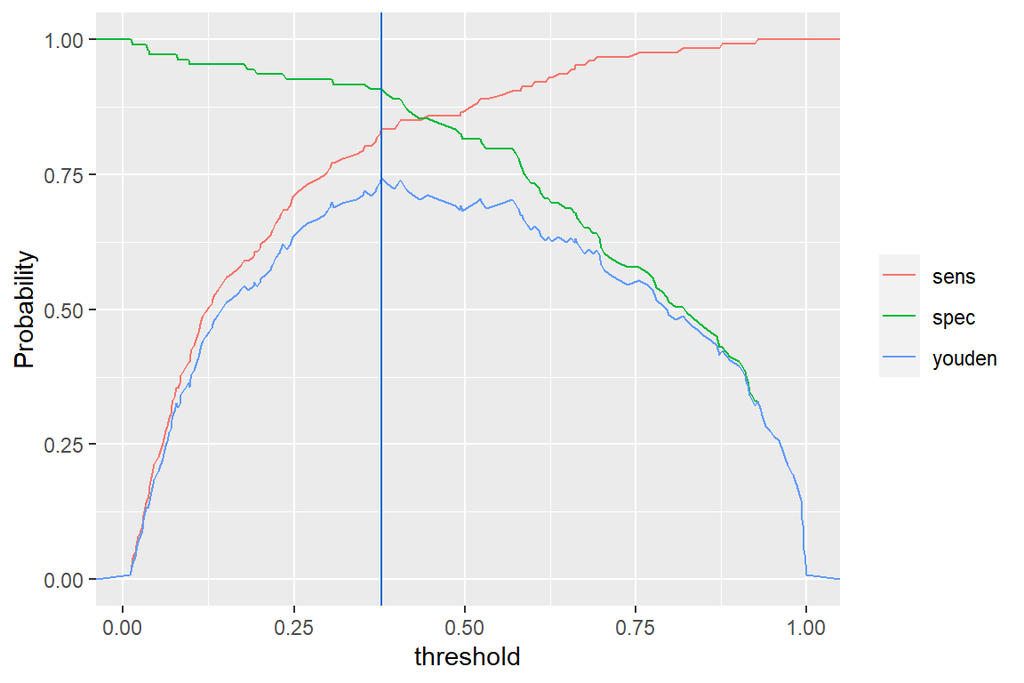

- Matrice des confusions avec seuillage définie par l’index de Youden

  |  | Confusion |
  | --- | --- |
  | Accuracy | 0.8686441 |
  | AccuracyLower | 0.8187591 |
  | AccuracyUpper | 0.9089752 |
  | Sensitivity | 0.9082569 |
  | Specificity | 0.8346457 |
  | Pos Pred Value | 0.8250000 |
  | Neg Pred Value | 0.9137931 |
  | F1 | 0.8646288 |
  | Threshold | 0.3780000 |

|  | 0 | 1 |
| --- | --- | --- |
| 0 | 99 | 21 |
| 1 | 10 | 106 |

## 3.4 Prédiction - déploiement

Nous utilisons maintenant le jeux de données de déploiement (partition 2) pour vérifier la qualité de la prédiction

```r
pred_dep <- predict(rf1, X_dep, type = 'prob')
head(pred_dep ,10) %>% kbl() %>%  kable_styling( position = "center", full_width = FALSE)
```

|  | 0 | 1 |
| --- | --- | --- |
| 10 | 0.986 | 0.014 |
| 12 | 0.058 | 0.942 |
| 18 | 0.997 | 0.003 |
| 35 | 0.988 | 0.012 |
| 40 | 0.136 | 0.864 |
| 43 | 0.988 | 0.012 |
| 44 | 0.976 | 0.024 |
| 55 | 0.172 | 0.828 |
| 58 | 0.506 | 0.494 |
| 59 | 0.681 | 0.319 |

- Courbe ROC

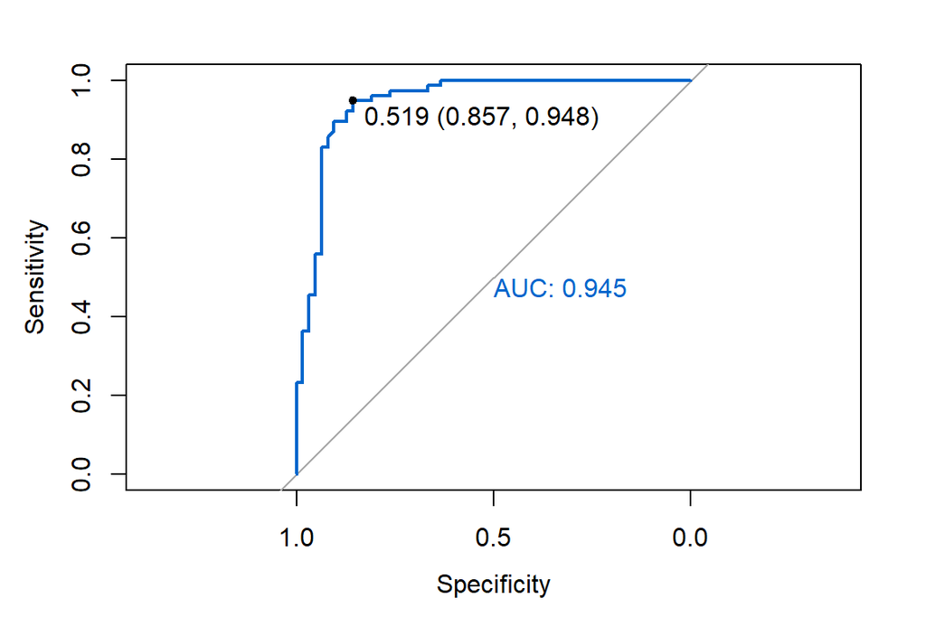

|  | roc |
| --- | --- |
| AUC_lower | 0.9056730 |
| AUC | 0.9454752 |
| AUC_upper | 0.9852773 |
| youden | 0.8051948 |

- Evolution des spécificités, sensibilités et seuillage

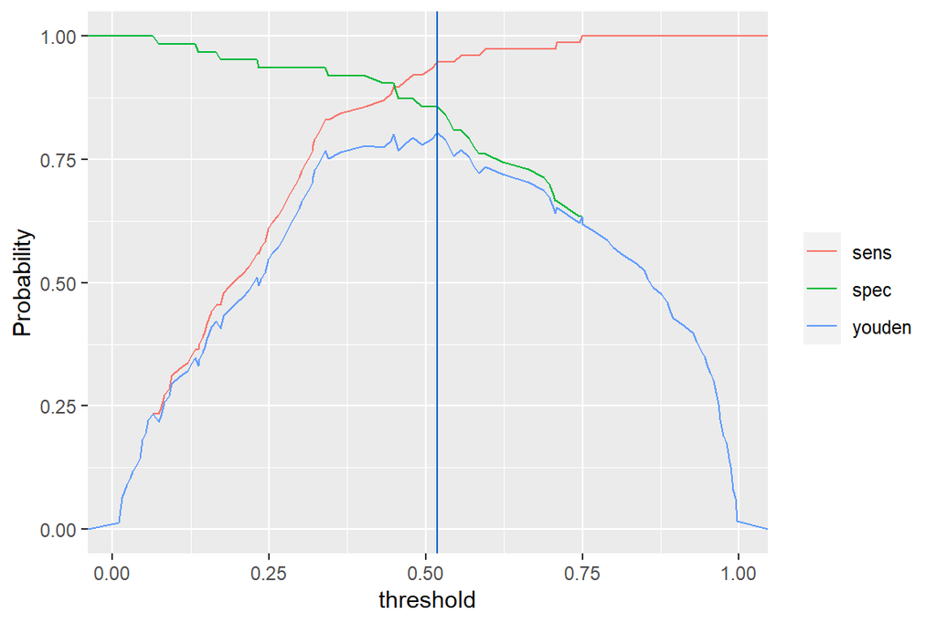

- Matrice des confusions avec seuillage définie par l’index de Youden

  |  | Confusion |
  | --- | --- |
  | Accuracy | 0.9071429 |
  | AccuracyLower | 0.8464462 |
  | AccuracyUpper | 0.9496265 |
  | Sensitivity | 0.8571429 |
  | Specificity | 0.9480519 |
  | Pos Pred Value | 0.9310345 |
  | Neg Pred Value | 0.8902439 |
  | F1 | 0.8925620 |
  | Threshold | 0.5190000 |

|  | 0 | 1 |
| --- | --- | --- |
| 0 | 54 | 4 |
| 1 | 9 | 73 |

# 4. **Les aides graphiques**

## 4.1 Graphique de proximité

Une fonctionnalité intéressante est l’affichage des proximités issus de la **prédiction réalisée par l’algorithme**. Ce graphique est représenté en deux dimensions (obtenus par diminution de dimensionalité - méthode MDS). Chaque individu est représenté par un point du graphique de sorte que la ‘distance’ entre deux individus soit la plus proche possible. Ce graphique permet de repérer d’éventuels individus atypique et les regroupements d’individus par classe. Pour obtenir le graphique, il est nécessaire d’ajouter l’option *proximity = T*

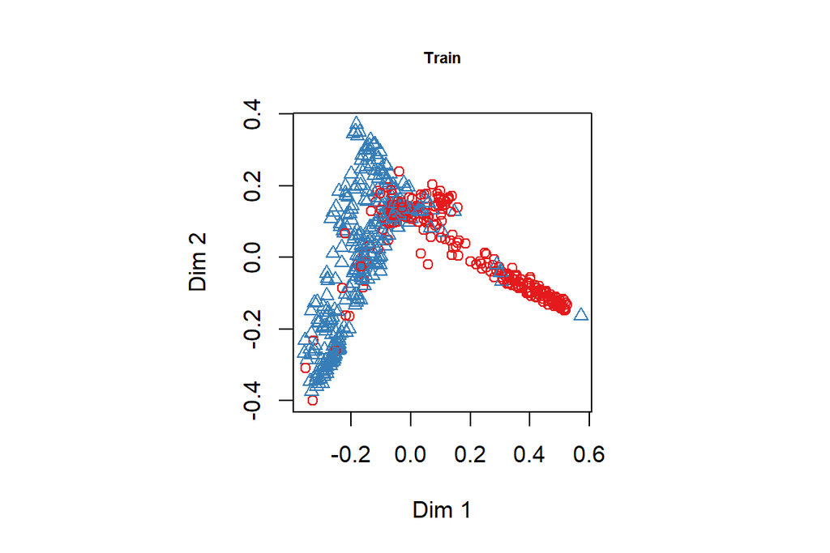

Dans la figure précédente, On observe une forme en U inversée. Les couleurs (bleu- rouge) des points correspondent au **classement effectué par l’algorithme**. La position des individus (et de leurs distance entre eux) est obtenue à partir d’une diminution de dimension par analyse factorielle (analogue au projection ACP) Comme on peut le constater, la méthode des forêts aléatoires permet une bonne classification des individus même dans le cas des zones à risque (partie supérieure du graphique: forte proximité des points) ou des individus dans les deux branches.

## 4.2 Importance des variables

Distribution de la profondeur des noeuds en fonction des variables

- Une fonctionnalité très intéressante est la mesure de l’importance de chaque variable. Nous avons vu en cours le principe général permettant d’estimer l’importance des variables par permutation aléatoire. Le graphique suivant fournit la distribution des profondeurs minimales par variable. Plus la profondeur est faible plus la variable est ‘importante’. Ce graphique utilise le critère *mean decrease Gini*

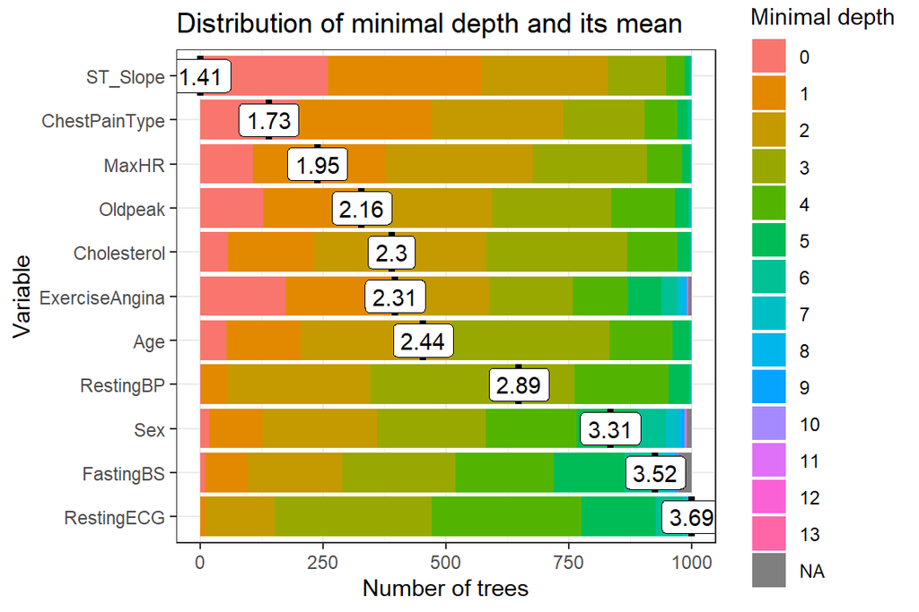

Importance des variables *Mean Decrease Gini* ou *Mean Decrease Accuracy*

- Il vaut mieux utiliser le critère *Mean Decrease Accuracy* car il est plus général. En effet, le critère “mean decrease Gini”” ne s’applique qu’à la construction des arbres CART. Le graphe suivant fournit l’importance des variables (en % da la totalité des importances de toutes les variables)

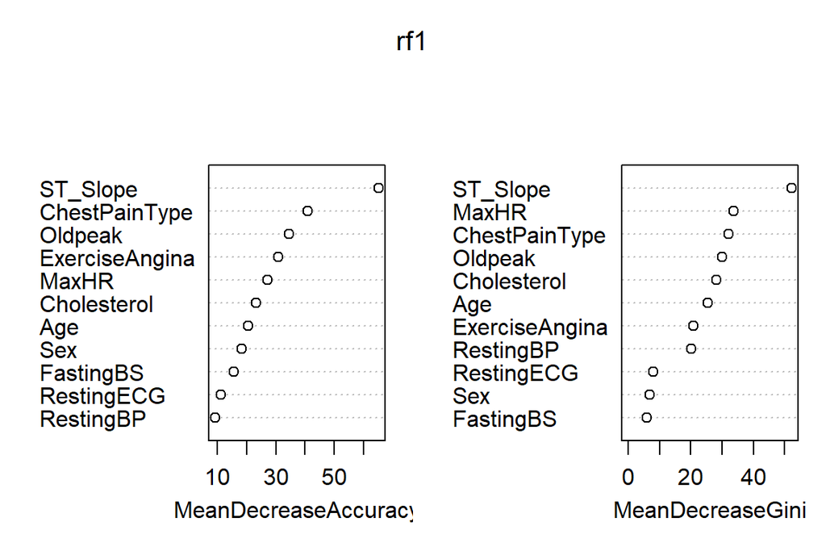

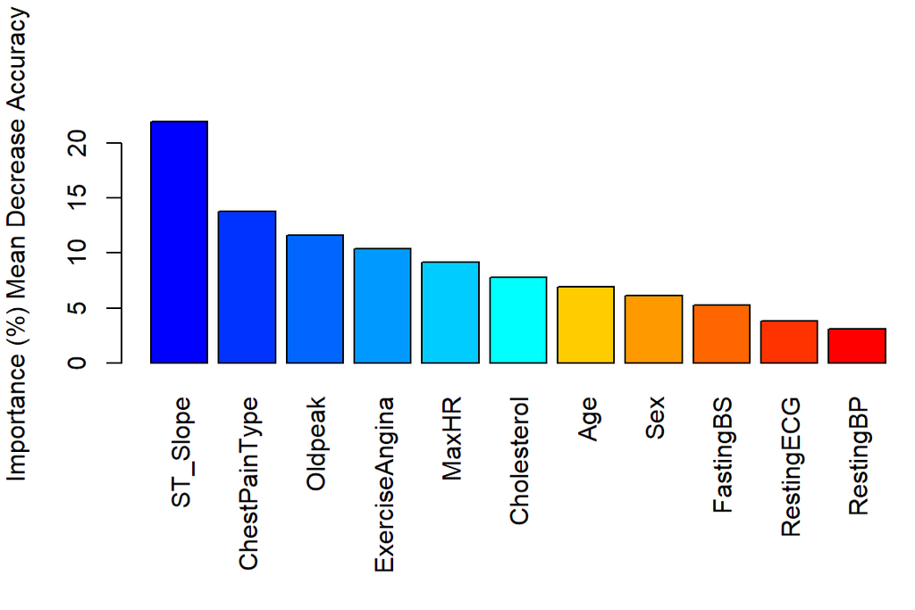

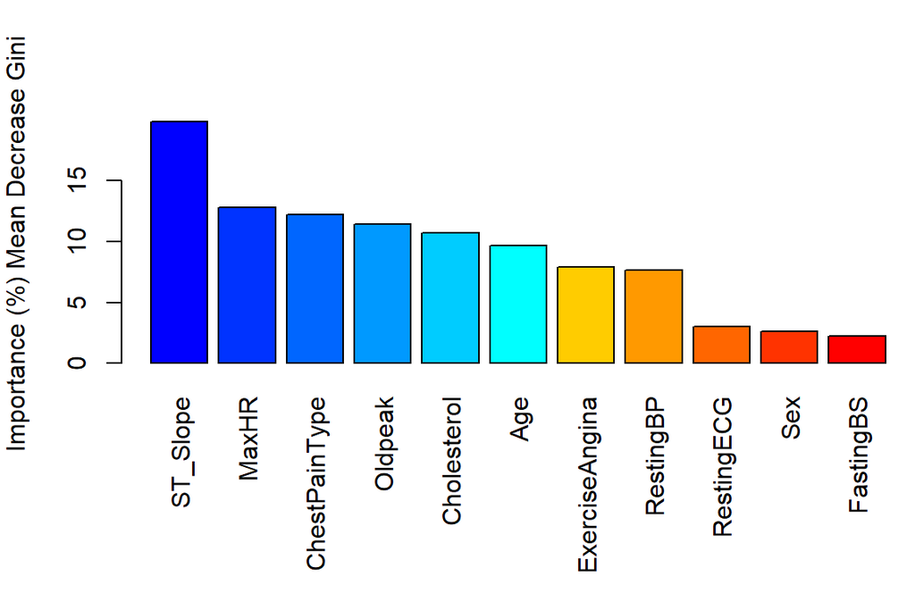

# 5.**TO DO Sélection des variables**

Les graphiques précédents montrent que certaines variables sont susceptibles d’être éliminées sans (trop) modifier la qualité de la prédiction voir l’améliorer. Effectuez de nouveau une procédure de random forest (entrainement-test et déploiement) après élimination d’une deux ou trois variables (voir plus) et comparez les résultats Concluez